# MODULE 1. Predicting Heart Attack. A Complete Machine Lerning Project Using R and Caret

### 4.2.12 slope

Slope of the ST segment during the most demanding part of the exercise

- Value 0: descending
- Value 1: flat
- Value 2: ascending

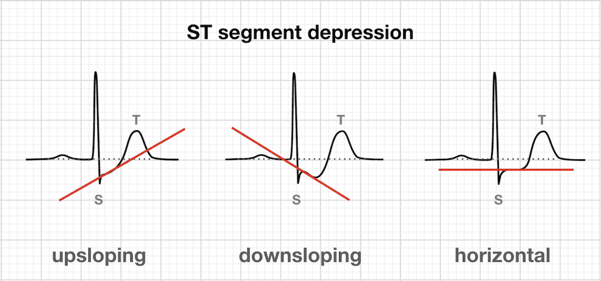

### 4.2.13 thal

Results of the blood flow observed via the radioactive dye.

- Value 0: NULL (dropped from the dataset previously)
- Value 1: fixed defect (no blood flow in some part of the heart)
- Value 2: normal blood flow
- Value 3: reversible defect (a blood flow is observed but it is not normal)

### 4.2.14 ca

This feature refers to the number of narrow blood vessels seen.

# 5 Models

To compare the models we first divide the dataset in a training set with 70% of instances and a test set with the rest of the instances. And this taking into account that the distribution of the target has to be the same in both sets.

The test set mimics data in the real world, it will only be used at the end of the project to get a more robust measure of the models on unseen data.

# 6 Bibliography

In addition to the links provided throughout the notebook, the following resources where also consulted to better understand the topic:

- “Heart disease and heart attacks”. Khan Academy. Link: https://www.khanacademy.org/science/health-and-medicine/healthcare-misc/v/heart-disease-and-heart-attacks
- “Cellular respiration introduction”. Khan Academy. Link: https://www.khanacademy.org/science/biology/cellular-respiration-and-fermentation/intro-to-cellular-respiration/v/introduction-to-cellular-respiration
- “Enfermedades cardiovasculares”. Organización Mundial de la Salud. Link: https://www.who.int/es/news-room/fact-sheets/detail/cardiovascular-diseases-(cvds)
- “Heart Disease”. Mayo Clinic. Link: https://www.mayoclinic.org/diseases-conditions/heart-disease/symptoms-causes/syc-20353118
- “Coronary artery disease”. Mayo Clinic. Link: https://www.mayoclinic.org/diseases-conditions/coronary-artery-disease/symptoms-causes/syc-20350613
- “Heart Attack (Myocardial Infarction)”. Cleveland Clinic. Link: https://my.clevelandclinic.org/health/diseases/16818-heart-attack-myocardial-infarction
- “Coronary Artery Disease”. Cleveland Clinic. Link: https://my.clevelandclinic.org/health/diseases/16898-coronary-artery-disease
- Institute of Medicine (US) Committee on Social Security Cardiovascular Disability Criteria. Cardiovascular Disability: Updating the Social Security Listings. Washington (DC): National Academies Press (US); 2010. 7, Ischemic Heart Disease. Available from: https://www.ncbi.nlm.nih.gov/books/NBK209964/

Hope this was helpful, feel free to give an upvote if you like it. Also, if I made any mistake or if you have any question feel free to write it in the comments 🙂